# Survey 11-13 Results

Last update: 2021-12-13

# IMMUNIZATION PASSPORTS

## Immunization or vaccination passports have been suggested as a way to safely resume international travel.

## How do you feel about the idea of using an immunization or vaccination passports?

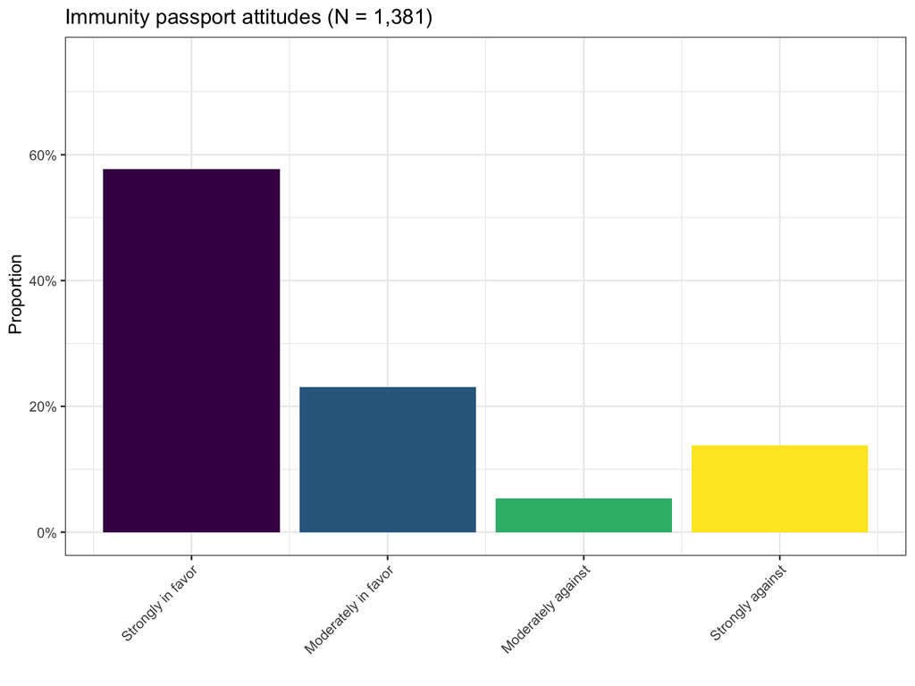

### Table corresponding to the graph above

1 = Strongly in favor

| immurec | n | prop |
| --- | --- | --- |
| 1 | 797 | 57.71 |
| 2 | 319 | 23.10 |
| 3 | 74 | 5.36 |
| 4 | 191 | 13.83 |

## ATTITUDES BY DEMOGRAPHICS

We would like to have the above plotted by various demographics, the numbers are shown below in separate tables. Bar plots would be great like the one above, perhaps different categories to be presented side by side. We would like to include proportion numbers in the plots as well.

Each table shows the number of responses to each level within each category - prop stands for proportion of responses within a given category (e.g. male).

### SEX

| sex | immurec | n | prop |
| --- | --- | --- | --- |
| male | strongly in favor | 194 | 0.56 |
| male | moderately in favor | 86 | 0.25 |
| male | moderately against | 23 | 0.07 |
| male | strongly against | 42 | 0.12 |
| female | strongly in favor | 596 | 0.58 |
| female | moderately in favor | 231 | 0.23 |
| female | moderately against | 51 | 0.05 |
| female | strongly against | 147 | 0.14 |

### AGE GROUP

| age_group | immurec | n | prop |
| --- | --- | --- | --- |
| 26 - 50y | strongly in favor | 303 | 47.72 |
| 26 - 50y | moderately in favor | 180 | 28.35 |
| 26 - 50y | moderately against | 45 | 7.09 |
| 26 - 50y | strongly against | 107 | 16.85 |
| over 51 | strongly in favor | 389 | 71.77 |
| over 51 | moderately in favor | 75 | 13.84 |
| over 51 | moderately against | 18 | 3.32 |
| over 51 | strongly against | 60 | 11.07 |
| under 25 | strongly in favor | 104 | 51.23 |
| under 25 | moderately in favor | 64 | 31.53 |
| under 25 | moderately against | 11 | 5.42 |
| under 25 | strongly against | 24 | 11.82 |

### EDUCATION

| edu | immurec | n | prop |
| --- | --- | --- | --- |
| primary | strongly in favor | 9 | 60.00 |
| primary | moderately in favor | 3 | 20.00 |
| primary | strongly against | 3 | 20.00 |
| secondary | strongly in favor | 161 | 57.91 |
| secondary | moderately in favor | 60 | 21.58 |
| secondary | moderately against | 12 | 4.32 |
| secondary | strongly against | 45 | 16.19 |
| college | strongly in favor | 271 | 56.81 |
| college | moderately in favor | 109 | 22.85 |
| college | moderately against | 24 | 5.03 |
| college | strongly against | 73 | 15.30 |
| graduate | strongly in favor | 353 | 58.93 |
| graduate | moderately in favor | 146 | 24.37 |
| graduate | moderately against | 36 | 6.01 |
| graduate | strongly against | 64 | 10.68 |

### INCOME

| hoinc | immurec | n | prop |
| --- | --- | --- | --- |
| bottom 3rd | strongly in favor | 124 | 52.10 |
| bottom 3rd | moderately in favor | 57 | 23.95 |
| bottom 3rd | moderately against | 15 | 6.30 |
| bottom 3rd | strongly against | 42 | 17.65 |
| middle 3rd | strongly in favor | 356 | 56.87 |
| middle 3rd | moderately in favor | 154 | 24.60 |
| middle 3rd | moderately against | 34 | 5.43 |
| middle 3rd | strongly against | 82 | 13.10 |
| top 3rd | strongly in favor | 204 | 66.02 |
| top 3rd | moderately in favor | 71 | 22.98 |
| top 3rd | moderately against | 13 | 4.21 |
| top 3rd | strongly against | 21 | 6.80 |

## To what extent would the introduction of ‘immunity passports’ influence your decision to get vaccinated?

Same as above, the plot below shows the overall sample, the subsequesnt tables are breaking it down by the demographic variables

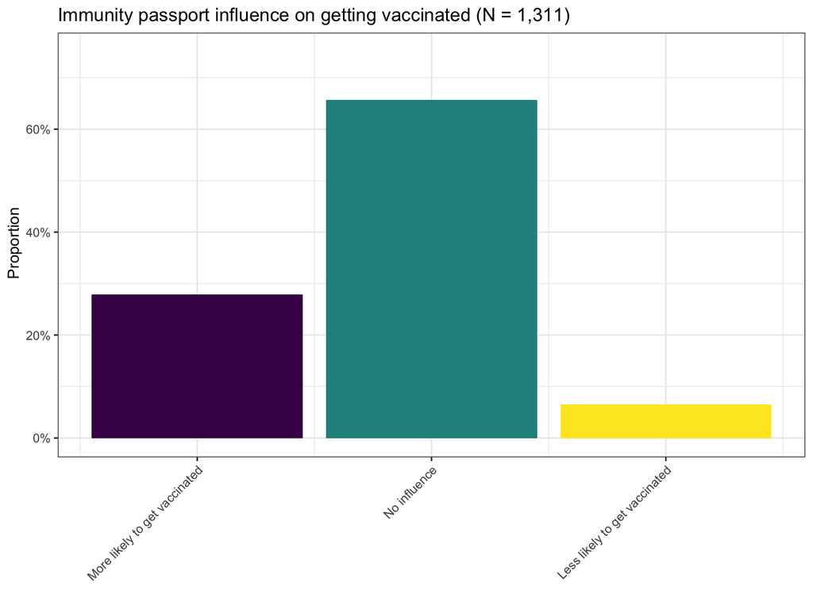

### Table corresponding to the plot

1 = It would make me more likely to get vaccinated

| immuinfl | n | sum | prop |
| --- | --- | --- | --- |
| 1 | 365 | 1311 | 27.84 |
| 2 | 861 | 1311 | 65.68 |
| 3 | 85 | 1311 | 6.48 |

### SEX

| sex | immuinfl | n | prop |
| --- | --- | --- | --- |
| male | more likely to get vaccinated | 96 | 29.00 |
| male | no influence | 217 | 65.56 |
| male | less likely | 18 | 5.44 |
| female | more likely to get vaccinated | 265 | 27.35 |
| female | no influence | 638 | 65.84 |
| female | less likely | 66 | 6.81 |

### AGE GROUP

| age_group | immuinfl | n | prop |
| --- | --- | --- | --- |
| 26 - 50y | more likely to get vaccinated | 151 | 25.25 |
| 26 - 50y | no influence | 398 | 66.56 |
| 26 - 50y | less likely | 49 | 8.19 |
| over 51 | more likely to get vaccinated | 133 | 25.78 |
| over 51 | no influence | 358 | 69.38 |
| over 51 | less likely | 25 | 4.84 |
| under 25 | more likely to get vaccinated | 81 | 41.33 |
| under 25 | no influence | 104 | 53.06 |
| under 25 | less likely | 11 | 5.61 |

### EDUCATION

| edu | immuinfl | n | prop |
| --- | --- | --- | --- |
| primary | more likely to get vaccinated | 6 | 42.86 |
| primary | no influence | 7 | 50.00 |
| primary | less likely | 1 | 7.14 |
| secondary | more likely to get vaccinated | 92 | 35.11 |
| secondary | no influence | 153 | 58.40 |
| secondary | less likely | 17 | 6.49 |
| college | more likely to get vaccinated | 122 | 26.93 |
| college | no influence | 290 | 64.02 |
| college | less likely | 41 | 9.05 |
| graduate | more likely to get vaccinated | 145 | 25.35 |
| graduate | no influence | 405 | 70.80 |
| graduate | less likely | 22 | 3.85 |

### INCOME

| hoinc | immuinfl | n | prop |
| --- | --- | --- | --- |
| bottom 3rd | more likely to get vaccinated | 54 | 24.32 |
| bottom 3rd | no influence | 148 | 66.67 |
| bottom 3rd | less likely | 20 | 9.01 |
| middle 3rd | more likely to get vaccinated | 166 | 27.90 |
| middle 3rd | no influence | 398 | 66.89 |
| middle 3rd | less likely | 31 | 5.21 |
| top 3rd | more likely to get vaccinated | 84 | 28.00 |
| top 3rd | no influence | 206 | 68.67 |
| top 3rd | less likely | 10 | 3.33 |